# CASE 2 - Jhon Heider Domingos Rezende

The first step in our analysis is define a working directory to both import the files which we’re going to use and save the outputs from the code.

```r
#### Set your working directory here to run the code ####

setwd("C:/Users/Jhon/Desktop/Challenge_4i")
getwd()
```

```
## [1] "C:/Users/Jhon/Desktop/Challenge_4i"
```

In this way, we can install and read all the required packages for this specific research.

```r
### Install packages ####


## External files opening
#install.packages("readr")

## Financial data
#install.packages("quantmod")
#install.packages("Quandl")
#install.packages("xts")
#install.packages("blscrapeR")

## Graphic Edition
#install.packages("dygraphs") # For More details:
                             # https://rstudio.github.io/dygraphs/
#install.packages("RColorBrewer")
#install.packages("ggplot2")
#install.packages("cowplot")
#install.packages("egg")
#install.packages("lubridate")
#install.packages("grid")
#install.packages("htmltools")
#install.packages("viridis")
#install.packages("hrbrthemes")

## Unit Root tests
#install.packages("urca")
#install.packages("fUnitRoots")

## Normality tests
#install.packages("normtest")

## ARCH Component test
#install.packages("aTSA")
#install.packages("FinTS")

## Regression Model tests
#install.packages("lmtest")
#install.packages("quantreg")
#install.packages("dynlm")

## Outliers detection
#install.packages("tsoutliers")

## Sctructural break tests
#install.packages("strucchange")

## Seasonal adjustment
#download.file("https://www.census.gov/ts/x13as/pc/x13as_V1.1_B19.zip", destfile = "./x13.zip")

#unzip("x13.zip")

#local <- paste(getwd(),"/x13as", sep = "")
#Sys.setenv(X13_PATH = local)

#install.packages("seasonal")

## Most common Time Series packages
#install.packages("rugarch")
#install.packages("fGarch")
#install.packages("tseries")
#install.packages("tstools")
#install.packages("forecast")
#install.packages("dplyr")
#install.packages("tsbox")
#install.packages("zoo")
#install.packages("xtsExtra", repos="http://R-Forge.R-project.org")
#install.packages("vars")
#install.packages("tidyverse")
#install.packages("mfilter")
#install.packages("Metrics")



####  Packages reading ####

library(dygraphs)
library(readr)
library(RColorBrewer)
library(fUnitRoots)
library(urca)
library(tseries)
library(lmtest)
library(tstools)
library(forecast)
library(strucchange)
library(normtest)
library(aTSA)
library(FinTS)
library(tsoutliers)
library(ggplot2)
library(quantmod)
library(fGarch)
library(rugarch)
library(data.table)
library(quantreg)
library(dynlm)
library(dplyr)
library(lubridate)
library(cowplot) # 1.0.0
library(egg) # 0.4.5
library(grid)
library(xts)
library(tsbox)
library(zoo)
library(vars)
library(tidyverse)
library(mFilter)
library(Metrics)
library(htmltools)
library(Quandl)
library(blscrapeR)
library(viridis)
library(hrbrthemes)
library(seasonal)
```

Here we’re importing the data set to be used along the code. The object ‘df’ will be used for all steps and it’ll suffers modifications when be necessary.

```r
df = read.csv("data_comexstat.csv")
is.na(df)
```

```r
#### Structure data ####

# Structure
head(df)
```

```
##         date product state       country   type  route   tons    usd
## 1 1997-01-01    corn    ES United States Import    Sea 44.045 113029
## 2 1997-01-01    corn    GO     Argentina Import Ground 54.000  36720
## 3 1997-01-01    corn    GO       Bolivia Export Ground  0.200    180
## 4 1997-01-01    corn    GO United States Export    Sea  3.488   5688
## 5 1997-01-01    corn    MG     Argentina Import Ground 27.000  18630
## 6 1997-01-01    corn    MS      Paraguay Export Ground 40.000  38700
```

```r
tail(df)
```

```
##              date product state          country   type  route      tons
## 117960 2019-12-01   wheat    SC         Paraguay Import Ground  1000.000
## 117961 2019-12-01   wheat    SP        Argentina Import    Sea 87124.765
## 117962 2019-12-01   wheat    SP          Ireland Export    Sea     0.500
## 117963 2019-12-01   wheat    SP          Lebanon Import    Sea     5.769
## 117964 2019-12-01   wheat    SP          Liberia Export  Other     0.025
## 117965 2019-12-01   wheat    SP Marshall Islands Export  Other     0.010
##             usd
## 117960   206000
## 117961 17897516
## 117962      477
## 117963     6726
## 117964       50
## 117965       85
```

```r
str(df)
```

```
## 'data.frame':    117965 obs. of  8 variables:
##  $ date   : Factor w/ 276 levels "1997-01-01","1997-02-01",..: 1 1 1 1 1 1 1 1 1 1 ...
##  $ product: Factor w/ 6 levels "corn","soybean_meal",..: 1 1 1 1 1 1 1 1 1 1 ...
##  $ state  : Factor w/ 27 levels "AC","AL","AM",..: 8 9 9 9 11 12 16 16 18 18 ...
##  $ country: Factor w/ 212 levels "Afghanistan",..: 200 8 22 200 8 147 8 201 8 133 ...
##  $ type   : Factor w/ 2 levels "Export","Import": 2 2 1 1 2 1 2 2 2 1 ...
##  $ route  : Factor w/ 5 levels "Air","Ground",..: 5 2 2 5 2 2 5 5 2 5 ...
##  $ tons   : num  44.05 54 0.2 3.49 27 ...
##  $ usd    : num  113029 36720 180 5688 18630 ...
```

As our first goal is to show the evolution of total monthly and total annual exports from Brazil (all states and to everywhere) of ‘soybeans’, ‘soybean oil’ and ‘soybean meal’, we’ll need to convert the observations from these variables into a annual frequency as well.

```r
# Number of periods of the data
levels(df$date) # 12 years - 276 months
```

Individual product analyses require a specific subset to each one of the products that will be studied. Here we’re splitting the soybeans, soybean meal and soybean oil exports from the global data set and converting them in both dollar and tons terms.

```r
# Separate the exports by product (soybeans, soybean_oil, soybean_meal)
levels(df$product)
```

```
## [1] "corn"         "soybean_meal" "soybean_oil"  "soybeans"     "sugar"
## [6] "wheat"
```

```r
levels(df$type)
```

```
## [1] "Export" "Import"
```

```r
soybeans = df[which(df$product=="soybeans" & df$type=="Export"),]
soybean_oil = df[which(df$product=="soybean_oil" & df$type=="Export"),]
soybean_meal = df[which(df$product=="soybean_meal" & df$type=="Export"),]

# Tons terms
sb_tons = tapply(soybeans$tons, soybeans$date, FUN = sum)
sbo_tons = tapply(soybean_oil$tons, soybean_oil$date, FUN = sum)
sbm_tons = tapply(soybean_meal$tons, soybean_meal$date, FUN = sum)

## USD terms
sb_usd = tapply(soybeans$usd, soybeans$date, FUN = sum)
sbo_usd = tapply(soybean_oil$usd, soybean_oil$date, FUN = sum)
sbm_usd = tapply(soybean_meal$usd, soybean_meal$date, FUN = sum)

rm(soybean_meal, soybean_oil, soybeans)
```

When the goal is to work with a historical path of products measured in monetary terms, it’s necessary convert all the values at a constant prices from a specific date. Along the rest of this code we’ll use December-2019 prices for all the analyses which will require this type of conversion.

```r
#### Constant Prices ####

cpi = read.csv("cpi.csv")
cpi = cpi[-24,-c(1,14,15)]
cpi = as.matrix(cpi)
cpi = as.vector(cpi)

# Dec,2019 = 100
cpi = (cpi/256.974)*100

# Brazil soybeans, soybeans oil and soybeans meal exports (Dec-2019 prices)

sb_usd = (sb_usd/cpi)*100
sbo_usd = (sbo_usd/cpi)*100
sbm_usd = (sbm_usd/cpi)*100
```

The following graphs represent the evolution of the Brazil’s soybeans, soybean meal and soybean oil exports in all the frequencies required in the work as well as all the historical data of the products in both dollar and tons terms from Jan,1997 to Dec,2019.

As we can see in the exports graphs with monthly frequency we’ll probably incur in series which present seasonality in their path. The specific procedures to deal with this kind of situation will be explored during the work.

```r
# Tons graph
dy_graph1 = list(
  dygraph(sb_tons/1000, main = "Brazil's soybean monthly exports in tons terms, 1997-2019", group = "tons") %>%
    dySeries(strokeWidth = 2, label = "Soybeans") %>%
    dyAxis("y",label = "Exports (thousand tons)") %>%
    dyAxis("x",drawGrid = FALSE,) %>%
    dyLegend(show = "follow") %>%
    dyOptions(colors = "#2b8cbe") %>%
    dyRangeSelector(dateWindow = c("1997-01-01", "2019-12-01")),
  dygraph(sbo_tons/1000, main = "Brazil's soybean monthly oil exports in tons terms, 1997-2019", group = "tons") %>%
    dySeries(strokeWidth = 2, label = "Soybeans Oil") %>%
    dyAxis("y",label = "Exports (thousand tons)") %>%
    dyAxis("x",drawGrid = FALSE) %>%
    dyLegend(show = "follow") %>%
    dyOptions(colors = "#31a354") %>%
    dyRangeSelector(dateWindow = c("1997-01-01", "2019-12-01")),
  dygraph(sbm_tons/1000, main = "Brazil soybean monthly meal exports in tons terms, 1997-2019", group = "tons") %>%
    dySeries(strokeWidth = 2, label = "Soybeans Meal") %>%
    dyAxis("y",label = "Exports (thousand tons)") %>%
    dyAxis("x",drawGrid = FALSE) %>%
    dyLegend(show = "follow") %>%
    dyLegend(show = "follow") %>%
    dyOptions(colors = "#f03b20") %>%
    dyRangeSelector(dateWindow = c("1997-01-01", "2019-12-01"))
) # end list

# Display
htmltools::browsable(htmltools::tagList(dy_graph1))
```

[interactive chart not shown]

The soybeans exports seem to have more seasonality than the other series.

```r
# USD
dy_graph2 = list(
  dygraph(sb_usd/10000000, main = "Brazil's soybean monthly exports in USD (Dec.2019=0)", group = "usd") %>%
    dySeries(strokeWidth = 2, label = "Soybeans") %>%
    dyAxis("y",label = "Value (ten millions USD)") %>%
    dyAxis("x",drawGrid = FALSE) %>%
    dyLegend(show = "follow") %>%
    dyOptions(colors = RColorBrewer::brewer.pal(4, "PiYG")) %>%
    dyRangeSelector(dateWindow = c("1997-01-01", "2019-12-01")),
  dygraph(sbo_usd/10000000, main = "Brazil's soybean monthly oil exports in USD (Dec.2019=0)", group = "usd") %>%
    dySeries(strokeWidth = 2, label = "Soybeans Oil") %>%
    dyAxis("y",label = "Value (ten millions USD)") %>%
    dyAxis("x",drawGrid = FALSE) %>%
    dyLegend(show = "follow") %>%
    dyOptions(colors = RColorBrewer::brewer.pal(3, "Dark2")) %>%
    dyRangeSelector(dateWindow = c("1997-01-01", "2019-12-01")),
  dygraph(sbm_usd/10000000, main = "Brazil's soybean monthly meal exports in USD (Dec.2019=0)", group = "usd") %>%
    dySeries(strokeWidth = 2, label = "Soybeans Meal", color = "blue") %>%
    dyAxis("y",label = "Value (ten millions USD)") %>%
    dyAxis("x",drawGrid = FALSE) %>%
    dyLegend(show = "follow") %>%
    dyLegend(show = "follow") %>%
    dyRangeSelector(dateWindow = c("1997-01-01", "2019-12-01"))
) # end list

# Display
htmltools::browsable(htmltools::tagList(dy_graph2))
```

[interactive chart not shown]

We also can see the clear difference between the total value of exports for each one of the three products in dollar terms (i.e. first Soybeans, second soybeans meal and third Soybeans oil).

```r
#### Getting annual evolution ####

# Date vector
Dtexports = seq( as.Date("1997-12-01"), as.Date("2019-12-01"), by="years")

# Annual tons
sb_annual = rollapply(sb_tons, width = 12, by = 12, align = "lef", FUN = "sum")
sbo_annual = rollapply(sbo_tons, width = 12, by = 12, align = "lef", FUN = "sum")
sbm_annual = rollapply(sbm_tons, width = 12, by = 12, align = "lef", FUN = "sum")

# Annual tons data frame
annual_tons = data.frame(Dtexports, sb_annual, sbo_annual, sbm_annual)

# Annual USD
sb_annual = rollapply(sb_usd, width = 12, by = 12, align = "lef", FUN = "sum")
sbo_annual = rollapply(sbo_usd, width = 12, by = 12, align = "lef", FUN = "sum")
sbm_annual = rollapply(sbm_usd, width = 12, by = 12, align = "lef", FUN = "sum")

# Annual USD data frame
annual_usd = data.frame(Dtexports, sb_annual, sbo_annual, sbm_annual)

# Remove the previous vector
rm(Dtexports, sb_annual,sbo_annual,sbm_annual)


# Convert to xts
annual_tons = xts(annual_tons[,-1], order.by = annual_tons[,1])
annual_usd = xts(annual_usd[,-1], order.by = annual_usd[,1])
```

When we observe the annual graphs for the same products we can notice that the seasonality effect is not so clear which suggest to us work with the data first in monthly frequency and then convert the series to annual frequency.

Moreover the soybeans’ growth from the pre-crises period is much bigger than the other products in our analysis suggesting the importance of it in both the commodities international market and its weight in the trade balance.

```r
dy_graph3 = list(
  dygraph(annual_usd/10000000, main = "Brazil's annual soybeans, soybeans oil and soybeans meal exports in USD (Dec.=2019)") %>%
  dySeries(strokeWidth = 2, strokePattern = "dashed", color = "blue", label = "Soybeans") %>%
  dySeries(strokeWidth = 2, color = "red", label = "Soybeans oil") %>%
  dySeries(strokeWidth = 2, drawPoints = TRUE, pointSize = 5,color = "green", pointShape = "square", label = "Soybeans meal") %>%
  dyAxis("y",label = "Value (ten millions USD)") %>%
  dyAxis("x",drawGrid = FALSE) %>%
  dyLegend(show = "always",width = 400, hideOnMouseOut = FALSE) %>%
  dyOptions() %>%
  dyRangeSelector(),

dygraph(annual_tons/1000, main = "Brazil's annual soybeans, soybeans oil and soybeans meal exports in tons") %>%
  dySeries(strokeWidth = 2, strokePattern = "dashed", color = "blue", label = "Soybeans") %>%
  dySeries(strokeWidth = 2, color = "red", label = "Soybeans oil") %>%
  dySeries(strokeWidth = 2, drawPoints = TRUE, pointSize = 5,color = "green", pointShape = "square", label = "Soybeans meal") %>%
  dyAxis("y",label = "Exports (thousand tons)") %>%
  dyAxis("x",drawGrid = FALSE) %>%
  dyLegend(show = "always",width = 400, hideOnMouseOut = FALSE) %>%
  dyOptions() %>%
  dyRangeSelector()

) # end of the list

htmltools::browsable(htmltools::tagList(dy_graph3))
```

[interactive chart not shown]

```r
rm(sb_usd, sbo_usd, sbm_usd, sb_tons, sbo_tons, sbm_tons, dy_graph1, dy_graph2, dy_graph3, annual_tons, annual_usd)
```

Now we procedure our study indicating the three most important products exported by Brazil in the last 5 years.

```r
# Last Five years
data = df
data$date <- as.Date(data$date, format= "%Y-%m-%d")

data = subset(data, date>= "2015-01-01" & date <= "2019-12-01")

# Only exports
data = data[which(data$type=="Export"),]

# Sum and order by product
res1 <- data %>%
  group_by(product) %>%
  summarize(sum(usd))
res1
```

```
## # A tibble: 6 x 2
##   product        `sum(usd)`
##   <fct>               <dbl>
## 1 corn          24447720910
## 2 soybean_meal  28407723437
## 3 soybean_oil    4795946873
## 4 soybeans     123325529857
## 5 sugar         40938486021
## 6 wheat           726945386
```

```r
# Rename the column names
colnames(res1) = c("Product", "Value")

res1 = with(res1, res1[order(Value, Product, decreasing = TRUE),])

res1$Product = c("Soybeans", "Sugar", "Soybeans Meal", "Corn", "Soybean Oil","Wheat")

res1 = res1[-c(4:6),]

# The products are: Soybeans, Sugar and Soybeans Meal.

# Separate the products
sb = data[which(data$product=="soybeans"),]
sugar = data[which(data$product=="sugar"),]
sb_meal = data[which(data$product=="soybean_meal"),]

# Monthly value exports
sb = tapply(sb$usd, sb$date, FUN = sum)
sugar = tapply(sugar$usd, sugar$date, FUN = sum)
sb_meal = tapply(sb_meal$usd, sb_meal$date, FUN = sum)

## Constant prices (dec.2019 = 100)

# CPI from 2015-01-01 to 2019-12-01
cpi1 = cpi[c(217:276)]
length(cpi1)
```

```
## [1] 60
```

```r
# Constant prices
sb = (sb/cpi1)*100
sugar = (sugar/cpi1)*100
sb_meal = (sb_meal/cpi1)*100

# Constant annual values
sb = rollapply(sb, width = 12, by = 12, align = "lef", FUN = "sum")
sugar = rollapply(sugar, width = 12, by = 12, align = "lef", FUN = "sum")
sb_meal = rollapply(sb_meal, width = 12, by = 12, align = "lef", FUN = "sum")


# Bind the variables
DtBar = seq( as.Date("2015-12-01"), as.Date("2019-12-01"), by="years")
prod_series = data.frame(DtBar, sb, sugar, sb_meal)
prod_series = xts(prod_series[,-1], order.by = prod_series[,1])

#Bar Chart
Product = c( "Soybeans","Sugar", "Soybeans Meal")
Value = c(sum(sb), sum(sugar) ,sum(sb_meal))
bar = data.frame(Product, Value)
```

In dollar terms we found out that those products are soybeans, sugar and soybeans meal for our specific sample. The results are presented in the following bar chart using the ggplot2 package considering the total sold of each product between the years 2015 and 2019.

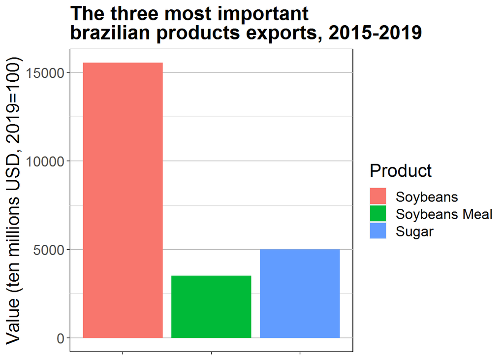

```r
# Bar Chart

bar_sb = ggplot(bar, aes(Product,Value/10000000, fill = Product)) +
  geom_bar(stat = "identity", na.rm = TRUE) +
  ggtitle("The three most important \nbrazilian products exports, 2015-2019") +
  ylab("Value (ten millions USD, 2019=100)") +
  theme(plot.title = element_text(lineheight = .8, face = "bold", size = 20)) +
    theme(axis.title.x = element_blank(),text = element_text(size=18), panel.background = element_rect(fill = "white", colour = "black"),
        panel.grid.major = element_line(size = 0.5, linetype = 'solid', colour = "gray"),
        panel.grid.minor = element_line(size = 0.25, linetype = 'solid', colour = "gray"), panel.grid.major.x = element_blank(), axis.text.x = element_blank())


# Visualize
bar_sb
```

The following graph represent the same products in their growth path during the same range of years. Even compared to the sugar exports, the soybeans exports persist as the most important exported by Brazil in the last five years.

```r
# TS Last Five Years
dygraph(prod_series/10000000, main = "Brazil's soybeans, sugar and soybeans meal exports, 2015-2019") %>%
  dySeries(strokeWidth = 2, strokePattern = "dashed", color = "blue", label = "Soybeans") %>%
  dySeries(strokeWidth = 2, color = "red", label = "Sugar") %>%
  dySeries(strokeWidth = 2, drawPoints = TRUE, pointSize = 5,color = "green", pointShape = "square", label = "Soybeans Meal") %>%
  dyAxis("y",label = "Value (ten millions USD, 2019=100)") %>%
  dyAxis("x",drawGrid = FALSE) %>%
  dyLegend(show = "always",width = 400, hideOnMouseOut = FALSE) %>%
  dyOptions() %>%
  dyRangeSelector()
```

[interactive chart not shown]

```r
### remove the previous vectors
rm(bar, bar_sb, cpi1, data, DtBar, prod_series, Product, res1, sb, sb_meal,sugar, Value)
```

The next step is define the main routes through which Brazil have been exporting ‘corn’ in the last few years. I chose a range period of ten years (2010 - 2019) to work with a relative number of observations as we’re working with annual frequency.

The pie chart clearly show to us the predominance of the sea rout as the most used route to export corn during our sample period. The choose of transportation for each type of product depends on a many factors as product weigh, cost transportation, distance between the traders and the natural facilities of each country.

```r
# Last 10 years
data = df
data$date <- as.Date(data$date, format= "%Y-%m-%d")

data = subset(data, date>= "2010-01-01" & date <= "2019-12-01")

# Only exports
data = data[which(data$type=="Export"),]

# Only corn
corn = data[which(data$product=="corn"),]

# Main Routes
levels(corn$route)
```

```
## [1] "Air"    "Ground" "Other"  "River"  "Sea"
```

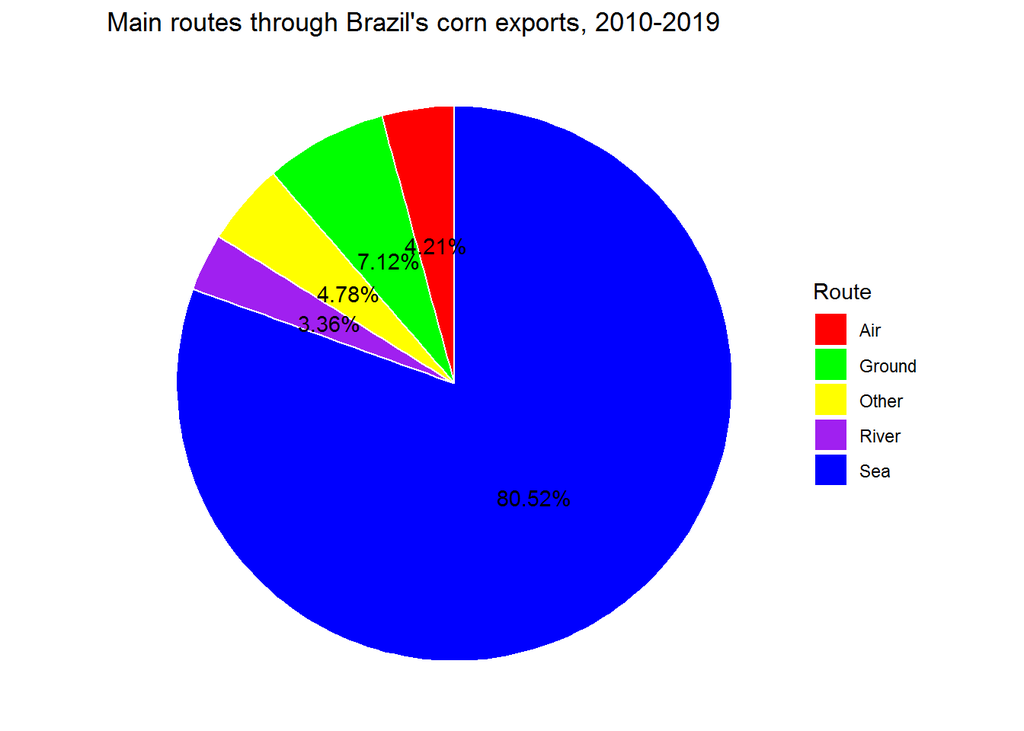

```r
routes = corn %>% count(route)
colnames(routes) = c("Route", "Number")

# Piechart
routes = routes %>%
  arrange(desc(Route)) %>%
  mutate(prop = Number / sum(routes$Number) * 100) %>%
  mutate(ypos = cumsum(prop)- 0.5*prop )


ggplot(routes, aes(x="", y=Number, fill = Route)) +
  ggtitle("Main routes through Brazil's corn exports, 2010-2019") +
  geom_bar(stat = "identity", width = 1, color = "white") +
  coord_polar("y", start = 0) +
  geom_text(aes(label = scales::percent(Number / sum(Number))),
            position = position_stack(vjust = 0.5)) +
  scale_fill_manual(values = c("red","green","yellow","purple", "blue")) +
  theme_void()
```

```r
# Remove the previous objects
rm(corn, data, routes)
```

Here we are trying to find out the countries which have been the most important trade partners for Brazil in terms of ‘corn’ and ‘sugar’ in the last 3 years. One more time we need to split the data set into subsets for each product of our study.

```r
# Last 3 years
data = df
data$date <- as.Date(data$date, format= "%Y-%m-%d")

data = subset(data, date>= "2017-01-01" & date <= "2019-12-01")

# Only exports
data = data[which(data$type=="Export"),]

# Corn and sugar
corn = data[which(data$product=="corn"),]
sugar = data[which(data$product=="sugar"),]

## Main brazilian trade partners of the previous two products


# Corn partners
corn_partners = tapply(corn$tons, corn$country, FUN = sum)
corn_partners = sort(corn_partners, decreasing = TRUE)
country = row.names(corn_partners)
corn_partners = cbind(country, corn_partners)
corn_partners = as.data.frame(corn_partners)
colnames(corn_partners) = c("Country", "Tons")

# Sugar partners
sugar_partners = tapply(sugar$tons, sugar$country, FUN = sum)
sugar_partners = sort(sugar_partners, decreasing = TRUE)
country = row.names(sugar_partners)
sugar_partners = cbind(country, sugar_partners)
sugar_partners = as.data.frame(sugar_partners)
colnames(sugar_partners) = c("Country", "Tons")

# The five most important partners
corn_partners = corn_partners[1:5,]
sugar_partners = sugar_partners[1:5,]

## Level of exports in tons terms of each country

# Corn
Iran = corn[which(corn$country=="Iran"),]
Iran = tapply(Iran$tons, Iran$date, FUN = sum)
Iran = sum(Iran)

Japan = corn[which(corn$country=="Japan"),]
Japan = tapply(Japan$tons, Japan$date, FUN = sum)
Japan = sum(Japan)

Vietnam = corn[which(corn$country=="Vietnam"),]
Vietnam = tapply(Vietnam$tons, Vietnam$date, FUN = sum)
Vietnam = sum(Vietnam)

Egypt = corn[which(corn$country=="Egypt"),]
Egypt = tapply(Egypt$tons, Egypt$date, FUN = sum)
Egypt = sum(Egypt)

Spain = corn[which(corn$country=="Spain"),]
Spain = tapply(Spain$tons, Spain$date, FUN = sum)
Spain = sum(Spain)


# Sugar
Algeria = sugar[which(sugar$country=="Algeria"),]
Algeria = tapply(Algeria$tons, Algeria$date, FUN = sum)
Algeria = sum(Algeria)

Bangladesh = sugar[which(sugar$country=="Bangladesh"),]
Bangladesh = tapply(Bangladesh$tons, Bangladesh$date, FUN = sum)
Bangladesh = sum(Bangladesh)

India = sugar[which(sugar$country=="India"),]
India = tapply(India$tons, India$date, FUN = sum)
India = sum(India)

UAE = sugar[which(sugar$country=="United Arab Emirates"),]
UAE = tapply(UAE$tons, UAE$date, FUN = sum)
UAE = sum(UAE)

SA = sugar[which(sugar$country=="Saudi Arabia"),]
SA = tapply(SA$tons, SA$date, FUN = sum)
SA = sum(SA)

# Data Frames - Sugar and Corn
Country = c("Iran", "Japan","Vietnam", "Egypt", "Spain")
Tons = c(Iran, Japan, Vietnam, Egypt, Spain)
corn = data.frame(Country, Tons)

Country = c("Algeria", "Bangladesh", "India","UAE", "SA")
Tons = c(Algeria, Bangladesh, India, UAE, SA)
sugar = data.frame(Country, Tons)
```

[figure not shown]

```r
# Corn - Bar Chart

corn_bar = ggplot(corn, aes(Country,Tons/1000000, fill = Country)) +
  geom_bar(stat = "identity", na.rm = TRUE) +
  ggtitle("Brazil's main corn export partners, 2017-2019") +
  ylab("Value (ten millions USD, 2019=100)") +
  theme(plot.title = element_text(lineheight = .8, face = "bold", size = 20)) + scale_fill_brewer(palette = "Set1") +
    theme(axis.title.x = element_blank(),text = element_text(size=18), panel.background = element_rect(fill = "white", colour = "black"),
        panel.grid.major = element_line(size = 0.5, linetype = 'solid', colour = "gray"),
        panel.grid.minor = element_line(size = 0.25, linetype = 'solid', colour = "gray"), panel.grid.major.x = element_blank(), axis.text.x = element_blank())

# Visualize
corn_bar
```

[figure not shown]

```r
# Sugar - Bar Chart
sugar_bar = ggplot(sugar, aes(Country ,Tons/1000000, fill = Country)) +
  geom_bar(stat = "identity", na.rm = TRUE) +
  ggtitle("Brazil's main sugar export partners, 2017-2019") +
  ylab("Value (ten millions USD, 2019=100)") +
  theme(plot.title = element_text(lineheight = .8, face = "bold", size = 20)) +
  scale_fill_brewer(palette = "Dark2") +
  theme(axis.title.x = element_blank(),text = element_text(size=18), panel.background = element_rect(fill = "white", colour = "black"),
        panel.grid.major = element_line(size = 0.5, linetype = 'solid', colour = "gray"),
        panel.grid.minor = element_line(size = 0.25, linetype = 'solid', colour = "gray"), panel.grid.major.x = element_blank(), axis.text.x = element_blank())

# Visualize
sugar_bar
```

```r
## Remove previous vectors
rm(Algeria, Bangladesh, corn, corn_bar, corn_partners, country, Country, data, Egypt, India, Iran, Japan, SA, Spain, sugar, sugar_bar, sugar_partners, UAE, Tons, Vietnam)
```

Now our goal is to find out the five most important states in terms of exports for each product in our data set. This time we’ll split the main data set in subsets of each one of the products and then filter the states which have more importance in value exported for each type of exports.

```r
# Only exports
data = df
data = data[which(data$type=="Export"),]

# Separate the products
levels(data$product)
```

```
## [1] "corn"         "soybean_meal" "soybean_oil"  "soybeans"     "sugar"
## [6] "wheat"
```

```r
corn = data[which(data$product=="corn"),]
sb = data[which(data$product=="soybeans"),]
sb_oil = data[which(data$product=="soybean_oil"),]
sb_meal = data[which(data$product=="soybean_meal"),]
sugar = data[which(data$product=="sugar"),]
wheat = data[which(data$product=="wheat"),]

# Main states for each product
corn_states = tapply(corn$tons, corn$state, FUN = sum)
corn_states = sort(corn_states, decreasing = TRUE)
State = row.names(corn_states)
corn_states = data.frame(State, corn_states)
colnames(corn_states) = c("State", "Tons")

sb_states = tapply(sb$tons, sb$state, FUN = sum)
sb_states = sort(sb_states, decreasing = TRUE)
State = row.names(sb_states)
sb_states = data.frame(State, sb_states)
colnames(sb_states) = c("State", "Tons")

sboil_states = tapply(sb_oil$tons, sb_oil$state, FUN = sum)
sboil_states = sort(sboil_states, decreasing = TRUE)
State = row.names(sboil_states)
sboil_states = data.frame(State, sboil_states)
colnames(sboil_states) = c("State", "Tons")

sbmeal_states = tapply(sb_meal$tons, sb_meal$state, FUN = sum)
sbmeal_states = sort(sbmeal_states, decreasing = TRUE)
State = row.names(sbmeal_states)
sbmeal_states = data.frame(State, sbmeal_states)
colnames(sbmeal_states) = c("State", "Tons")

sugar_states = tapply(sugar$tons, sugar$state, FUN = sum)
sugar_states = sort(sugar_states, decreasing = TRUE)
State = row.names(sugar_states)
sugar_states = data.frame(State, sugar_states)
colnames(sugar_states) = c("State", "Tons")

wheat_states = tapply(wheat$tons, wheat$state, FUN = sum)
wheat_states = sort(wheat_states, decreasing = TRUE)
State = row.names(wheat_states)
wheat_states = data.frame(State, wheat_states)
colnames(wheat_states) = c("State", "Tons")

# The five most important states
corn_states = corn_states[1:5,]
sb_states = sb_states[1:5,]
sboil_states = sboil_states[1:5,]
sbmeal_states = sbmeal_states[1:5,]
sugar_states = sugar_states[1:5,]
wheat_states = wheat_states[1:5,]
```

Unfortunately the volume of exports for wheat is very low comparing to the other products in our data set. This fact hide the results of exports for some of its states in the following graph, but the reader can verify in the numerical results that the most important exporting states for wheat are Rio Grande do Sul, Paraná, Santa Catarina, São Paulo and Mato Grosso do Sul, respectively.

For the other products the results are depicted at the other following graphs.

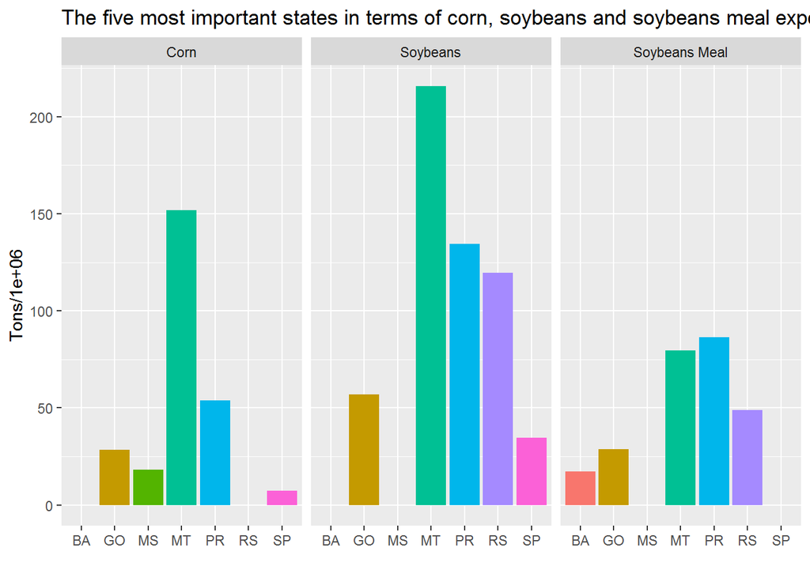

```r
corn_states$State = as.character(corn_states$State)
sb_states$State = as.character(sb_states$State)
sboil_states$State = as.character(sboil_states$State)
sbmeal_states$State = as.character(sbmeal_states$State)
sugar_states$State = as.character(sugar_states$State)
wheat_states$State = as.character(wheat_states$State)

##
Prod = c(rep("Corn",5), rep("Soybeans",5), rep("Soybeans Meal",5))

States = c(corn_states$State, sb_states$State, sbmeal_states$State)

Tons = c(corn_states$Tons, sb_states$Tons, sbmeal_states$Tons)

plot1 = data.frame(Prod, States, Tons)

###
Prod = c(rep("Soybeans Oil",5),rep("Wheat",5))
States = c(sboil_states$State, wheat_states$State)
Tons = c(sboil_states$Tons,wheat_states$Tons)
plot2 = data.frame(Prod, States, Tons)


ggplot(plot1, aes(fill=States, y=Tons/1000000, x=States)) +
    geom_bar(position="dodge", stat="identity") +
    ggtitle("The five most important states in terms of corn, soybeans and soybeans meal exports, 1997-2019") +
    facet_wrap(~Prod) +
    theme(legend.position="none") +
    xlab("")
```

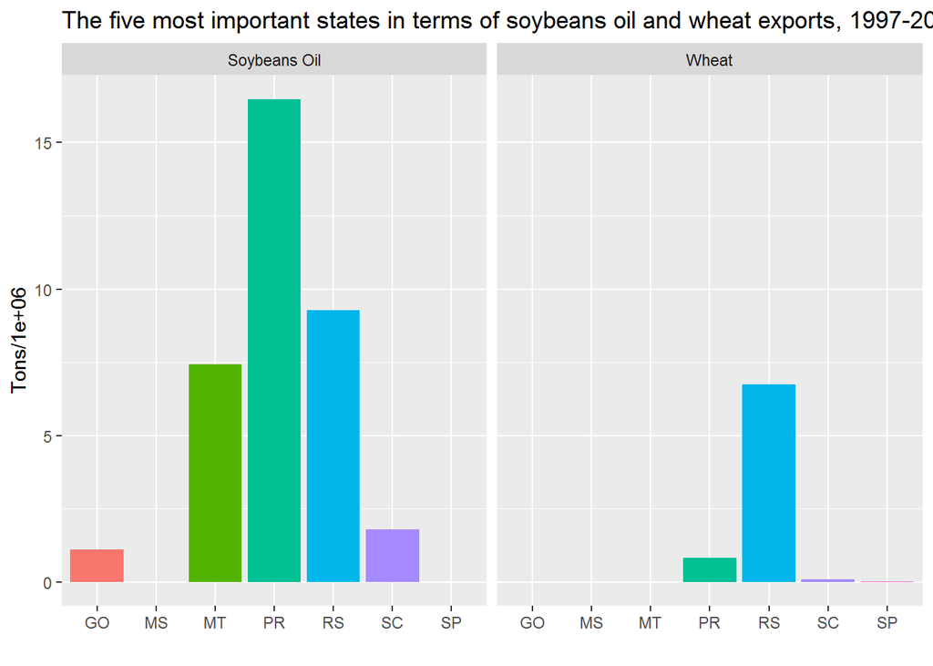

```r
ggplot(plot2, aes(fill=States, y=Tons/1000000, x=States)) +
    geom_bar(position="dodge", stat="identity") +
    ggtitle("The five most important states in terms of soybeans oil and wheat exports, 1997-2019") +
    facet_wrap(~Prod) +
    theme(legend.position="none") +
    xlab("")
```

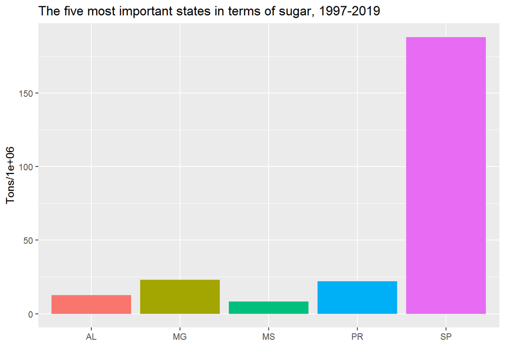

```r
ggplot(sugar_states, aes(State,fill=State, y=Tons/1000000)) +
    geom_bar(stat = "identity", na.rm = TRUE) +
    ggtitle("The five most important states in terms of sugar, 1997-2019") +
    theme(legend.position="none") +
    xlab("")
```

```r
rm(corn, corn_states, data, plot1, plot2, Prod, sb, sb_meal, sb_oil, sb_states, sbmeal_states, sboil_states, State, States, sugar, sugar_states, Tons, wheat, wheat_states)
```

As we mentioned before, the exports series contains seasonality in their path, at least as we saw in the visualizing procedure. Hence, we need to confirm this and other kind of characteristics running formal test which are able to tell us the real type of data that we’re working on.

Moreover, we will use the Augmented Dickey-Fuller and Phillips-Perron tests for identify the presence of unit root in the series and if it’s true, we’ll apply de log transformation in the data to convert the series into a stationary serie.

```r
# Only exports
data = df
data = data[which(data$type=="Export"),]

# Separate the products
sb = data[which(data$product=="soybeans"),]
sb_meal = data[which(data$product=="soybean_meal"),]
corn = data[which(data$product=="corn"),]

# Tons by month
sb = tapply(sb$tons, sb$date, FUN = sum)
sb_meal = tapply(sb_meal$tons, sb_meal$date, FUN = sum)
corn = tapply(corn$tons, corn$date, FUN = sum)

# Convert to time series object
sb = ts(sb, start = c(1997,1), end = c(2019,12), frequency = 12)
sb_meal = ts(sb_meal, start = c(1997,1), end = c(2019,12), frequency = 12)
corn = ts(corn, start = c(1997,1), end = c(2019,12), frequency = 12)

# Convert to a xts data frame
DtEx = seq(as.Date("1997-01-01"), as.Date("2019-12-01"), by = "month")
data = data.frame(DtEx, sb, sb_meal, corn)
data = xts(data[,-1], order.by = data[,1])
```

Another graphic way to observe a seasonal behavior in the data is combine the ‘plot’ and ‘decompose’ functions. Using this strategy we can see the other components from the series (trend, random, seasonal, observed) and confirm some of the main characteristics in the data set.

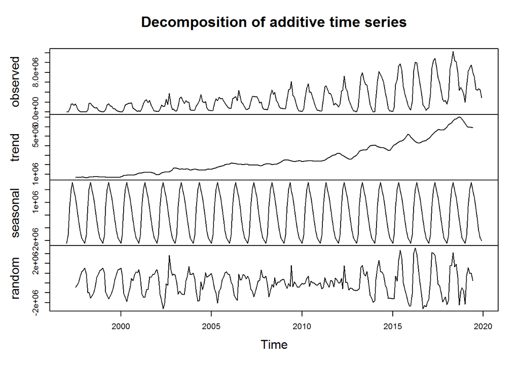

```r
# Graphic sazonality
plot(decompose(sb))
```

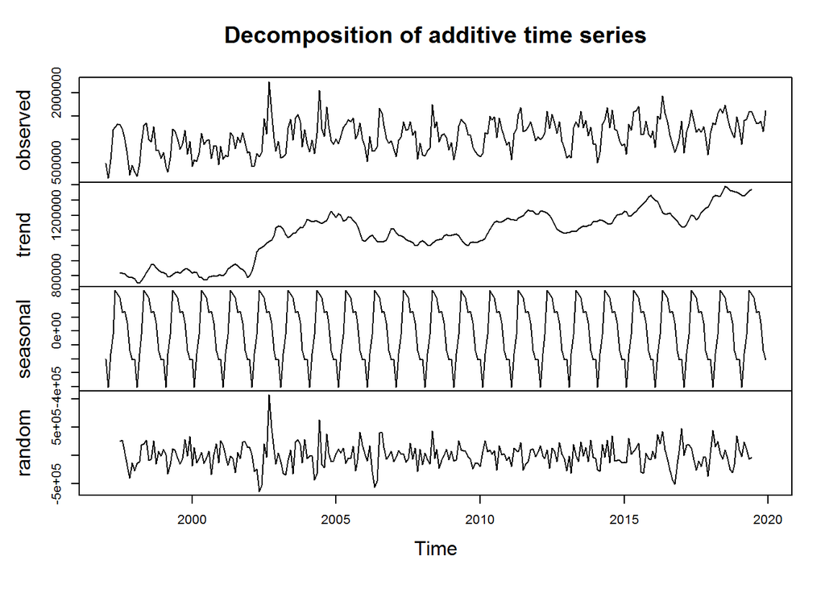

```r
plot(decompose(sb_meal))
```

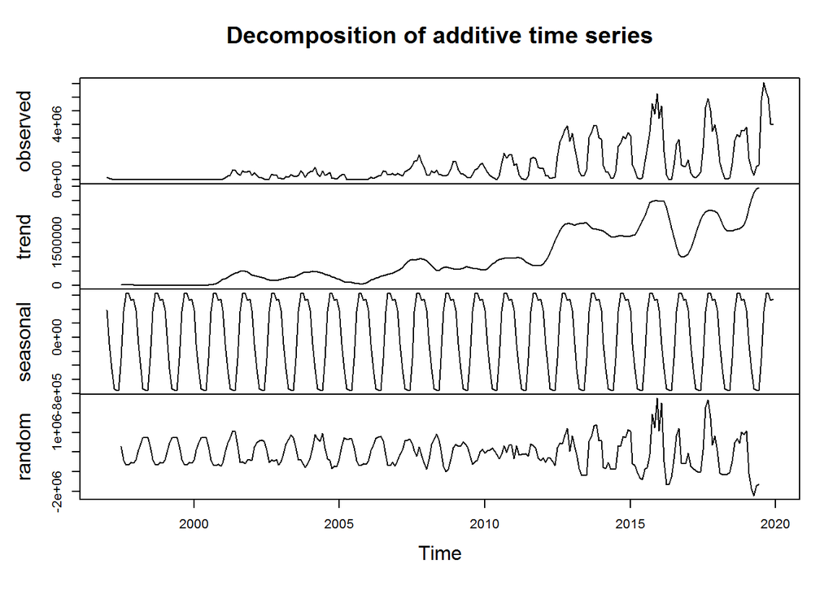

```r
plot(decompose(corn))
```

```r
rm(corn, DtEx, sb, sb_meal)
```

Now we can procedure verifying the existence of unit root in the data. In addition to the tests we’re going to use the Autocorrelation and Partial Autocorrelation functions (ACF and PACF, respectively) for each one of the series. Note the argument ‘lag.max’ in both functions depends on the total number of observation in each series. As we have a total of 276 observations (total months in 23 years) the maximum of lags in the function will be 69.

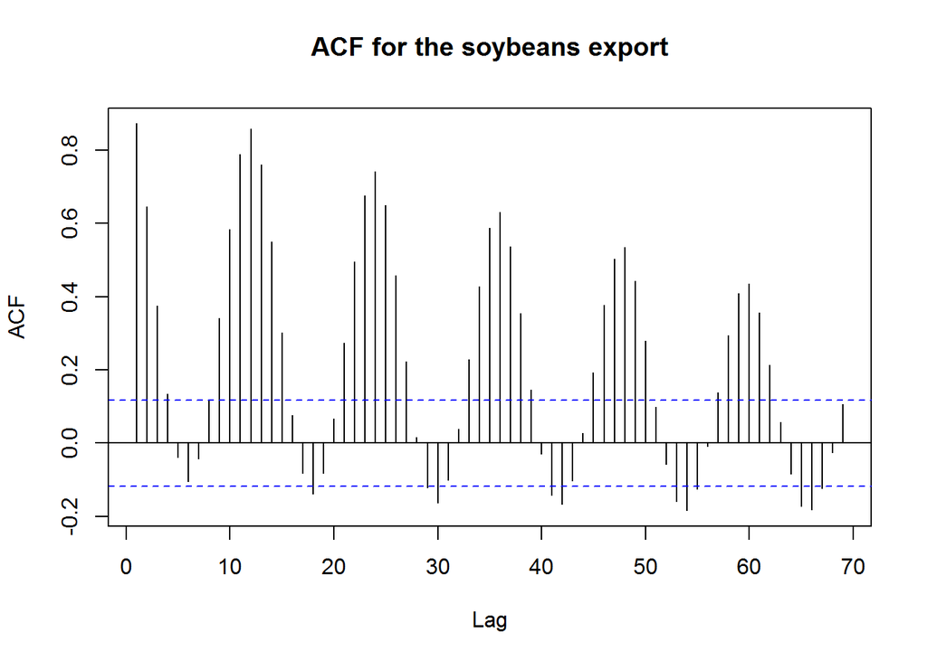

```r
#### Stationarity tests for the original series ####

## Soybeans - ACF and PACF
Acf(x = data$sb, lag.max = 69, type = 'correlation', plot = TRUE, main = "ACF for the soybeans export")
```

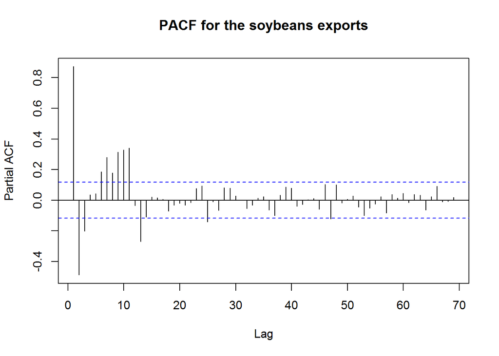

```r
Pacf(x = data$sb, lag.max = 69, plot = TRUE, main = "PACF for the soybeans exports") # T/4 - lag max
```

```r
## Soybeans - Augmented Dickey-Fuller Test for unit root
summary(ur.df(y = data$sb, type =  "none", selectlags = "AIC"))
```

```
##
## ###############################################
## # Augmented Dickey-Fuller Test Unit Root Test #
## ###############################################
##
## Test regression none
##
##
## Call:
## lm(formula = z.diff ~ z.lag.1 - 1 + z.diff.lag)
##
## Residuals:
##      Min       1Q   Median       3Q      Max
## -3035601  -288091    57390   619348  5788515
##
## Coefficients:
##            Estimate Std. Error t value Pr(>|t|)
## z.lag.1    -0.09135    0.01932  -4.727 3.66e-06 ***
## z.diff.lag  0.44768    0.05451   8.214 8.76e-15 ***
## ---
## Signif. codes:  0 '***' 0.001 '**' 0.01 '*' 0.05 '.' 0.1 ' ' 1
##
## Residual standard error: 1188000 on 272 degrees of freedom
## Multiple R-squared:  0.2232, Adjusted R-squared:  0.2175
## F-statistic: 39.07 on 2 and 272 DF,  p-value: 1.212e-15
##
##
## Value of test-statistic is: -4.7269
##
## Critical values for test statistics:
##       1pct  5pct 10pct
## tau1 -2.58 -1.95 -1.62
```

```r
summary(ur.df(y = data$sb, type =  "drift", selectlags = "AIC"))
```

```
##
## ###############################################
## # Augmented Dickey-Fuller Test Unit Root Test #
## ###############################################
##
## Test regression drift
##
##
## Call:
## lm(formula = z.diff ~ z.lag.1 + 1 + z.diff.lag)
##
## Residuals:
##      Min       1Q   Median       3Q      Max
## -3105148  -569065  -249064   341919  5404347
##
## Coefficients:
##               Estimate Std. Error t value Pr(>|t|)
## (Intercept)  5.075e+05  9.831e+04   5.162 4.74e-07 ***
## z.lag.1     -1.893e-01  2.648e-02  -7.148 8.19e-12 ***
## z.diff.lag   4.940e-01  5.287e-02   9.344  < 2e-16 ***
## ---
## Signif. codes:  0 '***' 0.001 '**' 0.01 '*' 0.05 '.' 0.1 ' ' 1
##
## Residual standard error: 1135000 on 271 degrees of freedom
## Multiple R-squared:  0.2927, Adjusted R-squared:  0.2875
## F-statistic: 56.07 on 2 and 271 DF,  p-value: < 2.2e-16
##
##
## Value of test-statistic is: -7.1477 25.5469
##
## Critical values for test statistics:
##       1pct  5pct 10pct
## tau2 -3.44 -2.87 -2.57
## phi1  6.47  4.61  3.79
```

```r
summary(ur.df(y = data$sb, type =  "trend", selectlags = "AIC"))
```

```
##
## ###############################################
## # Augmented Dickey-Fuller Test Unit Root Test #
## ###############################################
##
## Test regression trend
##
##
## Call:
## lm(formula = z.diff ~ z.lag.1 + 1 + tt + z.diff.lag)
##
## Residuals:
##      Min       1Q   Median       3Q      Max
## -2878572  -633848  -113906   446979  4678928
##
## Coefficients:
##               Estimate Std. Error t value Pr(>|t|)
## (Intercept) -2.611e+04  1.308e+05  -0.200    0.842
## z.lag.1     -3.052e-01  3.204e-02  -9.526  < 2e-16 ***
## tt           6.080e+03  1.049e+03   5.794 1.91e-08 ***
## z.diff.lag   5.530e-01  5.098e-02  10.847  < 2e-16 ***
## ---
## Signif. codes:  0 '***' 0.001 '**' 0.01 '*' 0.05 '.' 0.1 ' ' 1
##
## Residual standard error: 1073000 on 270 degrees of freedom
## Multiple R-squared:  0.3709, Adjusted R-squared:  0.3639
## F-statistic: 53.06 on 3 and 270 DF,  p-value: < 2.2e-16
##
##
## Value of test-statistic is: -9.5265 30.2664 45.3977
##
## Critical values for test statistics:
##       1pct  5pct 10pct
## tau3 -3.98 -3.42 -3.13
## phi2  6.15  4.71  4.05
## phi3  8.34  6.30  5.36
```

```r
## Soybeans - Phillips-Perron test for unit root
summary(ur.pp(x = data$sb, type = "Z-tau", model = "constant"))
```

```
##
## ##################################
## # Phillips-Perron Unit Root Test #
## ##################################
##
## Test regression with intercept
##
##
## Call:
## lm(formula = y ~ y.l1)
##
## Residuals:
##      Min       1Q   Median       3Q      Max
## -2987628  -688873  -349974   395362  6248078
##
## Coefficients:
##              Estimate Std. Error t value Pr(>|t|)
## (Intercept) 3.490e+05  1.106e+05   3.155  0.00178 **
## y.l1        8.727e-01  2.933e-02  29.752  < 2e-16 ***
## ---
## Signif. codes:  0 '***' 0.001 '**' 0.01 '*' 0.05 '.' 0.1 ' ' 1
##
## Residual standard error: 1301000 on 273 degrees of freedom
## Multiple R-squared:  0.7643, Adjusted R-squared:  0.7634
## F-statistic: 885.2 on 1 and 273 DF,  p-value: < 2.2e-16
##
##
## Value of test-statistic, type: Z-tau  is: -5.3599
##
##          aux. Z statistics
## Z-tau-mu            3.8574
##
## Critical values for Z statistics:
##                      1pct      5pct     10pct
## critical values -3.455701 -2.872167 -2.572388
```

```r
summary(ur.pp(x = data$sb, type = "Z-tau", model = "trend"))
```

```
##
## ##################################
## # Phillips-Perron Unit Root Test #
## ##################################
##
## Test regression with intercept and trend
##
##
## Call:
## lm(formula = y ~ y.l1 + trend)
##
## Residuals:
##      Min       1Q   Median       3Q      Max
## -3080045  -725679  -235366   488950  5855302
##
## Coefficients:
##              Estimate Std. Error t value Pr(>|t|)
## (Intercept) 5.291e+05  1.233e+05   4.291 2.48e-05 ***
## y.l1        8.042e-01  3.630e-02  22.153  < 2e-16 ***
## trend       3.807e+03  1.223e+03   3.113  0.00205 **
## ---
## Signif. codes:  0 '***' 0.001 '**' 0.01 '*' 0.05 '.' 0.1 ' ' 1
##
## Residual standard error: 1281000 on 272 degrees of freedom
## Multiple R-squared:  0.7724, Adjusted R-squared:  0.7707
## F-statistic: 461.5 on 2 and 272 DF,  p-value: < 2.2e-16
##
##
## Value of test-statistic, type: Z-tau  is: -6.5636
##
##            aux. Z statistics
## Z-tau-mu              1.6518
## Z-tau-beta            3.8572
##
## Critical values for Z statistics:
##                      1pct      5pct     10pct
## critical values -3.994802 -3.427523 -3.136793
```

[figure not shown]

```r
## Soybeans Meal - ACF and PACF
Acf(x = data$sb_meal, lag.max = 69, type = 'correlation', plot = TRUE, main = "ACF for soybeans exports")
```

[figure not shown]

```r
Pacf(x = data$sb_meal, lag.max = 69, plot = TRUE, main = "PACF for soybeans exports") # T/4 - lag max
```

```r
## Soybeans Meal - Augmented Dickey-Fuller Test for unit root
summary(ur.df(y = data$sb_meal, type =  "none", selectlags = "AIC"))
```

```
##
## ###############################################
## # Augmented Dickey-Fuller Test Unit Root Test #
## ###############################################
##
## Test regression none
##
##
## Call:
## lm(formula = z.diff ~ z.lag.1 - 1 + z.diff.lag)
##
## Residuals:
##     Min      1Q  Median      3Q     Max
## -672239 -191144   19246  200168 1066101
##
## Coefficients:
##            Estimate Std. Error t value Pr(>|t|)
## z.lag.1    -0.02445    0.01614  -1.514    0.131
## z.diff.lag -0.23773    0.05918  -4.017 7.63e-05 ***
## ---
## Signif. codes:  0 '***' 0.001 '**' 0.01 '*' 0.05 '.' 0.1 ' ' 1
##
## Residual standard error: 299700 on 272 degrees of freedom
## Multiple R-squared:  0.07033,    Adjusted R-squared:  0.0635
## F-statistic: 10.29 on 2 and 272 DF,  p-value: 4.925e-05
##
##
## Value of test-statistic is: -1.5144
##
## Critical values for test statistics:
##       1pct  5pct 10pct
## tau1 -2.58 -1.95 -1.62
```

```r
summary(ur.df(y = data$sb_meal, type =  "drift", selectlags = "AIC"))
```

```
##
## ###############################################
## # Augmented Dickey-Fuller Test Unit Root Test #
## ###############################################
##
## Test regression drift
##
##
## Call:
## lm(formula = z.diff ~ z.lag.1 + 1 + z.diff.lag)
##
## Residuals:
##     Min      1Q  Median      3Q     Max
## -608535 -191136  -17867  181872 1108205
##
## Coefficients:
##               Estimate Std. Error t value Pr(>|t|)
## (Intercept)  4.232e+05  6.048e+04   6.997 2.05e-11 ***
## z.lag.1     -3.871e-01  5.393e-02  -7.178 6.78e-12 ***
## z.diff.lag  -5.961e-02  6.021e-02  -0.990    0.323
## ---
## Signif. codes:  0 '***' 0.001 '**' 0.01 '*' 0.05 '.' 0.1 ' ' 1
##
## Residual standard error: 276300 on 271 degrees of freedom
## Multiple R-squared:  0.2124, Adjusted R-squared:  0.2065
## F-statistic: 36.53 on 2 and 271 DF,  p-value: 8.969e-15
##
##
## Value of test-statistic is: -7.1784 25.8272
##
## Critical values for test statistics:
##       1pct  5pct 10pct
## tau2 -3.44 -2.87 -2.57
## phi1  6.47  4.61  3.79
```

```r
summary(ur.df(y = data$sb_meal, type =  "trend", selectlags = "AIC"))
```

```
##
## ###############################################
## # Augmented Dickey-Fuller Test Unit Root Test #
## ###############################################
##
## Test regression trend
##
##
## Call:
## lm(formula = z.diff ~ z.lag.1 + 1 + tt + z.diff.lag)
##
## Residuals:
##     Min      1Q  Median      3Q     Max
## -618198 -192856  -29178  179774 1190490
##
## Coefficients:
##               Estimate Std. Error t value Pr(>|t|)
## (Intercept)  4.150e+05  5.918e+04   7.012 1.89e-11 ***
## z.lag.1     -4.896e-01  5.966e-02  -8.207 9.40e-15 ***
## tt           8.575e+02  2.335e+02   3.672  0.00029 ***
## z.diff.lag  -6.777e-03  6.060e-02  -0.112  0.91105
## ---
## Signif. codes:  0 '***' 0.001 '**' 0.01 '*' 0.05 '.' 0.1 ' ' 1
##
## Residual standard error: 270200 on 270 degrees of freedom
## Multiple R-squared:  0.2498, Adjusted R-squared:  0.2415
## F-statistic: 29.97 on 3 and 270 DF,  p-value: < 2.2e-16
##
##
## Value of test-statistic is: -8.2066 22.5052 33.6928
##
## Critical values for test statistics:
##       1pct  5pct 10pct
## tau3 -3.98 -3.42 -3.13
## phi2  6.15  4.71  4.05
## phi3  8.34  6.30  5.36
```

```r
## Soybeans Meal - Phillips-Perron test for unit root
summary(ur.pp(x = data$sb_meal, type = "Z-tau", model = "constant"))
```

```
##
## ##################################
## # Phillips-Perron Unit Root Test #
## ##################################
##
## Test regression with intercept
##
##
## Call:
## lm(formula = y ~ y.l1)
##
## Residuals:
##     Min      1Q  Median      3Q     Max
## -592343 -189677  -12277  183127 1130418
##
## Coefficients:
##              Estimate Std. Error t value Pr(>|t|)
## (Intercept) 4.357e+05  5.474e+04    7.96 4.65e-14 ***
## y.l1        5.993e-01  4.838e-02   12.39  < 2e-16 ***
## ---
## Signif. codes:  0 '***' 0.001 '**' 0.01 '*' 0.05 '.' 0.1 ' ' 1
##
## Residual standard error: 277900 on 273 degrees of freedom
## Multiple R-squared:  0.3598, Adjusted R-squared:  0.3575
## F-statistic: 153.4 on 1 and 273 DF,  p-value: < 2.2e-16
##
##
## Value of test-statistic, type: Z-tau  is: -8.3468
##
##          aux. Z statistics
## Z-tau-mu            8.0204
##
## Critical values for Z statistics:
##                      1pct      5pct     10pct
## critical values -3.455701 -2.872167 -2.572388
```

```r
summary(ur.pp(x = data$sb_meal, type = "Z-tau", model = "trend"))
```

```
##
## ##################################
## # Phillips-Perron Unit Root Test #
## ##################################
##
## Test regression with intercept and trend
##
##
## Call:
## lm(formula = y ~ y.l1 + trend)
##
## Residuals:
##     Min      1Q  Median      3Q     Max
## -623332 -197520  -29395  182180 1196718
##
## Coefficients:
##              Estimate Std. Error t value Pr(>|t|)
## (Intercept) 5.280e+05  5.829e+04   9.058  < 2e-16 ***
## y.l1        5.132e-01  5.200e-02   9.870  < 2e-16 ***
## trend       8.911e+02  2.268e+02   3.928 0.000109 ***
## ---
## Signif. codes:  0 '***' 0.001 '**' 0.01 '*' 0.05 '.' 0.1 ' ' 1
##
## Residual standard error: 270800 on 272 degrees of freedom
## Multiple R-squared:  0.3942, Adjusted R-squared:  0.3897
## F-statistic:  88.5 on 2 and 272 DF,  p-value: < 2.2e-16
##
##
## Value of test-statistic, type: Z-tau  is: -9.2643
##
##            aux. Z statistics
## Z-tau-mu              9.5262
## Z-tau-beta            3.8810
##
## Critical values for Z statistics:
##                      1pct      5pct     10pct
## critical values -3.994802 -3.427523 -3.136793
```

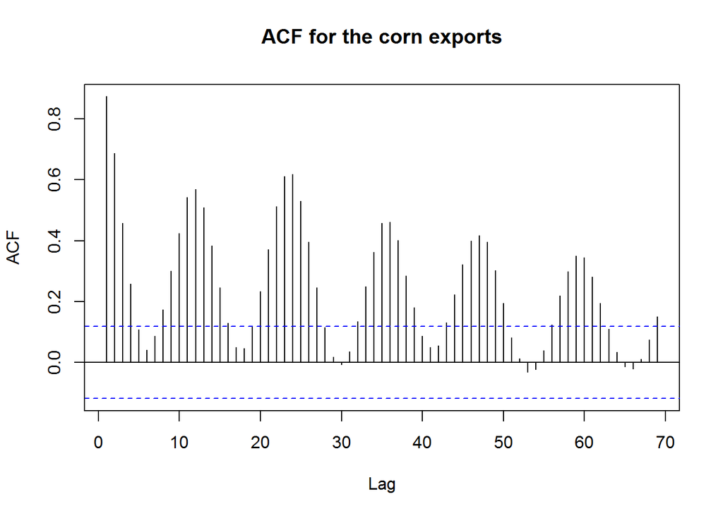

```r
## Corn - ACF and PACF
Acf(x = data$corn, lag.max = 69, type = 'correlation', plot = TRUE, main = "ACF for the corn exports")
```

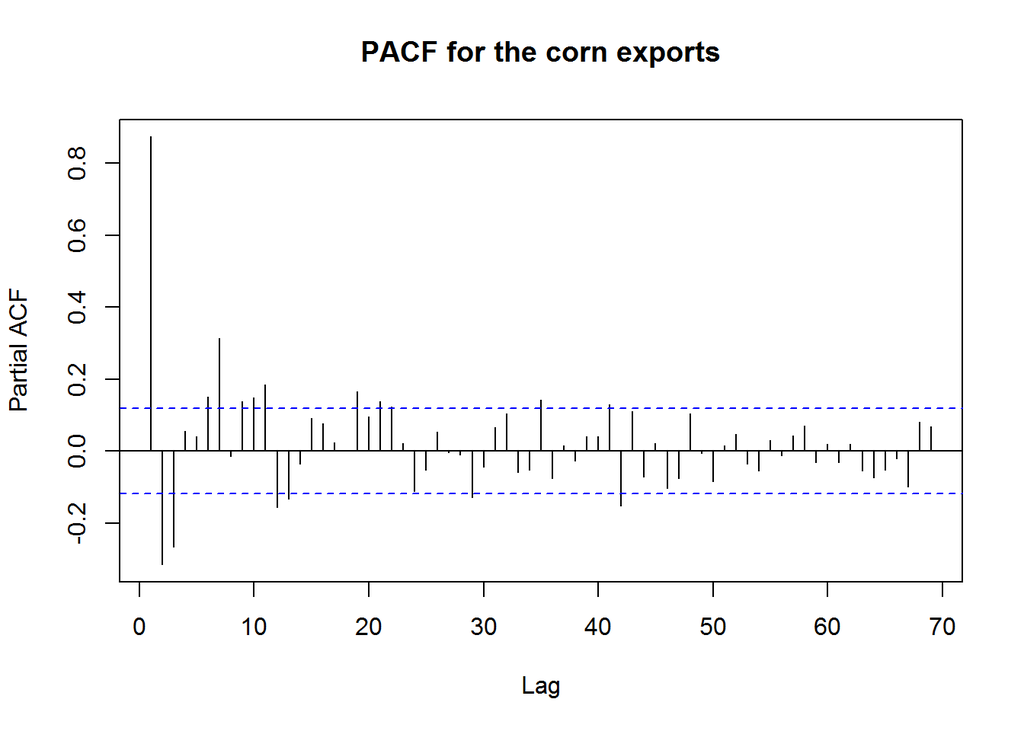

```r
Pacf(x = data$corn, lag.max = 69, plot = TRUE, main = "PACF for the corn exports") # T/4 - lag max
```

```r
## Corn - Augmented Dickey-Fuller Test for unit root
summary(ur.df(y = data$corn, type =  "none", selectlags = "AIC"))
```

```
##
## ###############################################
## # Augmented Dickey-Fuller Test Unit Root Test #
## ###############################################
##
## Test regression none
##
##
## Call:
## lm(formula = z.diff ~ z.lag.1 - 1 + z.diff.lag)
##
## Residuals:
##      Min       1Q   Median       3Q      Max
## -3100163   -50054    11875   225238  4755339
##
## Coefficients:
##            Estimate Std. Error t value Pr(>|t|)
## z.lag.1    -0.09839    0.02346  -4.193 3.72e-05 ***
## z.diff.lag  0.30338    0.05843   5.192 4.07e-07 ***
## ---
## Signif. codes:  0 '***' 0.001 '**' 0.01 '*' 0.05 '.' 0.1 ' ' 1
##
## Residual standard error: 661800 on 272 degrees of freedom
## Multiple R-squared:  0.1186, Adjusted R-squared:  0.1121
## F-statistic:  18.3 on 2 and 272 DF,  p-value: 3.509e-08
##
##
## Value of test-statistic is: -4.1932
##
## Critical values for test statistics:
##       1pct  5pct 10pct
## tau1 -2.58 -1.95 -1.62
```

```r
summary(ur.df(y = data$corn, type =  "drift", selectlags = "AIC"))
```

```
##
## ###############################################
## # Augmented Dickey-Fuller Test Unit Root Test #
## ###############################################
##
## Test regression drift
##
##
## Call:
## lm(formula = z.diff ~ z.lag.1 + 1 + z.diff.lag)
##
## Residuals:
##      Min       1Q   Median       3Q      Max
## -2986595  -184726  -110425    95127  4648275
##
## Coefficients:
##               Estimate Std. Error t value Pr(>|t|)
## (Intercept)  1.650e+05  4.832e+04   3.414 0.000737 ***
## z.lag.1     -1.549e-01  2.835e-02  -5.464 1.06e-07 ***
## z.diff.lag   3.303e-01  5.786e-02   5.710 2.97e-08 ***
## ---
## Signif. codes:  0 '***' 0.001 '**' 0.01 '*' 0.05 '.' 0.1 ' ' 1
##
## Residual standard error: 649200 on 271 degrees of freedom
## Multiple R-squared:  0.1546, Adjusted R-squared:  0.1483
## F-statistic: 24.77 on 2 and 271 DF,  p-value: 1.314e-10
##
##
## Value of test-statistic is: -5.4639 14.9653
##
## Critical values for test statistics:
##       1pct  5pct 10pct
## tau2 -3.44 -2.87 -2.57
## phi1  6.47  4.61  3.79
```